# 7. Critical Values

Cheng Peng

West Chester University

# 1 Review Topics

We first review the Five Rules of Derivative

These rules of the derivative will be used frequently throughout the semester.

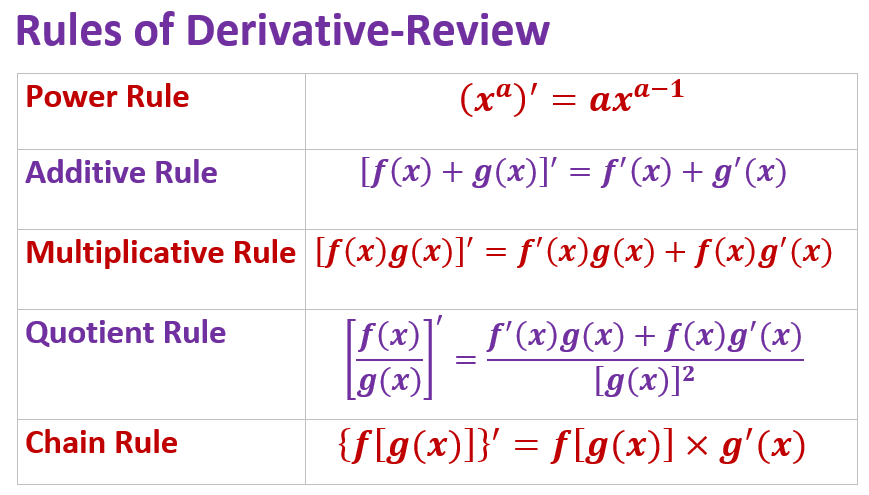

We will apply derivatives to solve real-world optimization problems maximizing profit or revenue and minimizing the cost, etc. This note focuses on the concepts of critical values and using derivation to find critical values.

# 2 Increasing and decreasing functions

We reviewed monotonic function in the first week. The following figures demonstrate increasing and decreasing functions.

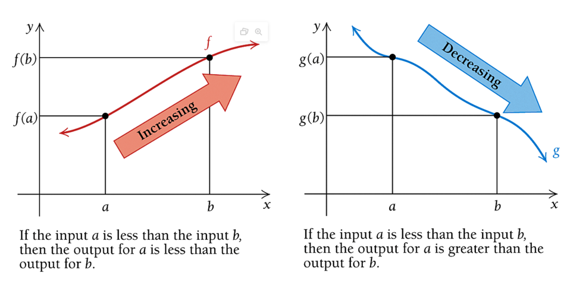

Using the definition of the derivative, we can see that

- If $f(x)$ is increasing over $[a, b]$, then $f^\prime(x) > 0$ over $[a, b]$;
- If $f(x)$ is decreasing over $[a, b]$, then $f^\prime(x) < 0$ over $[a, b]$.

Graphically, we have the following figures explain the above observation

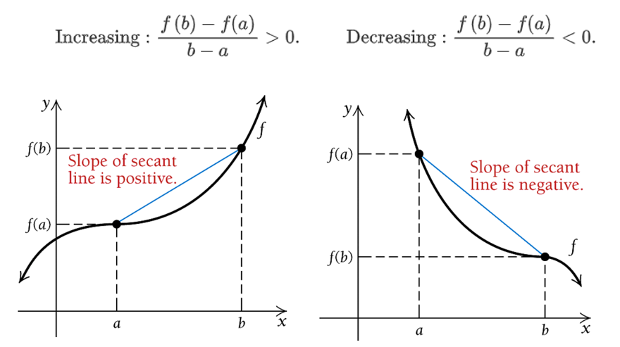

We next formalize the above observation and present the following theorem.

**Theorem 1**: Let $f(x)$ be differential over interval $I = [a,b]$

1. If $f^\prime(x) > 0$ for all x in $I = [a, b]$, then $f(x)$ is increasing over $I=[a, b]$
2. If $f^\prime(x) < 0$ for all x in $I = [a, b]$, then $f(x)$ is deceasing over $I=[a,b]$.

**Example 1**: Using the above Theorem 1 to find the intervals on which the function $f(x) = x^3/3 - x + 2/3$.

**Solution**: The following figure answers the above question.

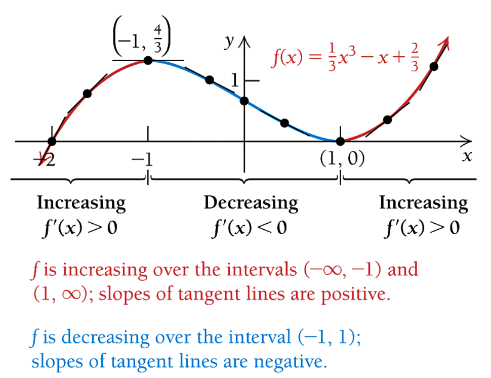

# 3 Critival Value

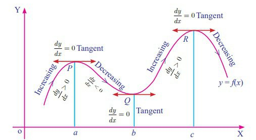

**Definition**: A **critical value** of a function $f(x)$ is any number $c$ in the **domain** of $f(x)$ for which the tangent line at $(c, f(c))$ is horizontal or for which the derivative does **not** eixst. That is, $c$ is a **critical** value if $f(c)$ exists and

$$f^\prime(c) = 0 ~ ~ \text{or}~~ f^\prime(c) ~ \text{does not exist}$$
If $c$ is a critical value of $f(x)$, then $(c, f(c))$ is called a **critical point**.

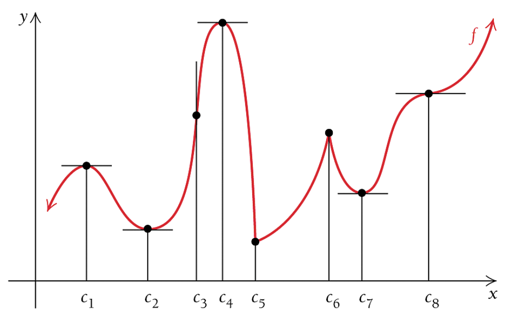

All labeled points on the above figure are critical points since the corresponding derivative is either 0 or does not exist.

1. $f^\prime(x) = 0$ for $x = c_1, c_2, c_4, c_7$ and $c_8$. That is, the tangent line to the graph is horizontal at these values.
2. $f^\prime(x)$ does not exist for $x = c_3, c_5$ and $c_6$. The tangent line is vertical at $c_3$ and there are corners at both $c_5$ and $c_6$.

**Example 2** Find critical values of the function $f(x) = x^3/3 - x + 2/3$.

**Solution**: By the definition, we need to the solution to $f^\prime(x) = 0$ and those values on which the derivative of $f(x)$ does not exist.

Note that $f^\prime(x) = x^2 - 1$. Therefore, equation $x^2 -1 = 0$ has solutions $x = \pm 1$. These two critical values are the same as shown in example 1.

# 4 Relative (Local) Maximum and Minimum Values

Graphically, the local maximum and minimum are the second coordinates of the points that are labeled in the following figure.

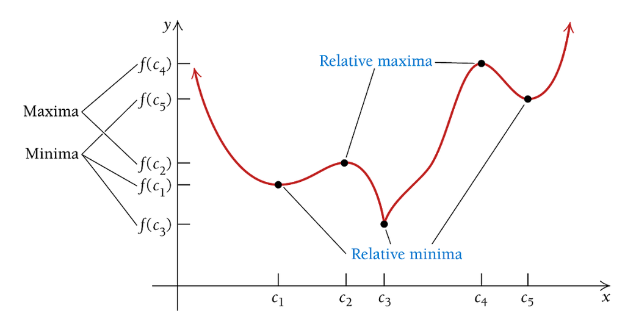

Here, $f(c_2)$ and $f(c_4)$ are each an example of a **relative**, or **local**, **maximum (plural: maxima)**, and $f(c_1), f(c_3)$ and $f(c_5)$ are each an example of a relative, or local, **minimum (plural: minima)**. Collectively, maximum and minimum values are called **extrema (singular: extremum)**. Note that a relative minimum can be greater than a relative maximum; for example, $f(c_5) > f(c_2)$ in the graph at the bottom of the preceding page.

Note that x-values at which a continuous function has relative extrema are those values for which the derivative is 0 or for which the derivative does not exist—the critical values.

**Theorem**: If a function $f(x)$ has a relative extreme value $f(c)$ on an **open interval**, then $c$ is a critical value, and

$$f^\prime(c) = 0 ~~\text{or}~~f^\prime(c) ~~ \text{does not exist.}$$

The next theorem gives a test for relative extrema: **The First-Derivative Test for Relative Extrema**

**Theorem**: For any continuous function $f(x)$ that has exactly one critical value $c$ over an **open interval** $(a, b)$:

1. $f(x)$ has a relative minimum at $c$ if $f^\prime(x) < 0$ on $(a, c)$ and $f^\prime(x) > 0$ on $(c, b)$. That is, $f(x)$ is decreasing to the left of $c$ and increasing to the right of $c$.
2. 1. $f(x)$ has a relative maximum at $c$ if $f^\prime(x) > 0$ on $(a, c)$ and $f^\prime(x) < 0$ on $(c, b)$. That is, $f(x)$ is increasing to the left of $c$ and decreasing to the right of $c$.
3. $f(x)$ has neither a relative maximum nor a relative minimum at $c$ if $f^\prime(x)$ has the same sign on both sides of $c$.

**Example 3**: Consider the relative maximum and relative minimum of function $f(x) = 4x^3 - 9x^2 - 30x + 25$.

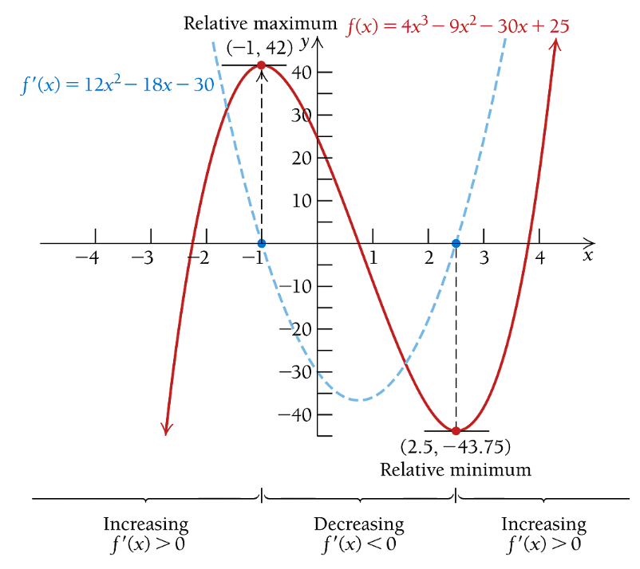